# Setup of data for an onlineforecast model

Peder Bacher

2020-09-07

## Intro

This vignette explains how to setup data consisting of observations and forecasts, such that it can be used for onlineforecast models. A generic introduction and description is in available in [onlineforecasting](https://onlineforecasting.org/articles/onlineforecasting.pdf). The code is available here. More information on onlineforecasting.org.

## Data example

First load the package:

```r
## Load the package
library(onlineforecast)
```

In the package different data sets are included. The `Dbuilding` holds the data used for the example of heat load forecasting in the building-heat-load-forecasting vignette.

When the package is loaded the data is also loaded, so we can access it directly. Let’s start out by:

```r
## Keep it in D to simplify notation
D <- Dbuilding
```

The class is ‘data.ĺist’:

```r
## The class of D
class(D)
```

```
##     [1] "data.list"
```

Actually, a ‘data.list’ is simply a ‘list’, but we made the class ‘data.list’ in order to have functions for the particular format of data - the format is explained in this document.

It consists of vectors of time, vectors of observations (model output) and data.frames of forecasts (model input):

```r
## Print the names to see the variables in the data
names(D)
```

```
##     [1] "t"             "heatload"      "heatloadtotal" "Taobs"
##     [5] "Iobs"          "Ta"            "I"
```

An overview of the content can be generated by:

```r
summary(D)
```

```
##                   Length Class      Mode
##     t             1824   POSIXct    numeric
##     heatload      1824   -none-     numeric
##     heatloadtotal 1824   -none-     numeric
##     Taobs         1824   -none-     numeric
##     Iobs          1824   -none-     numeric
##     Ta              36   data.frame list
##     I               36   data.frame list
```

where it can be seen that `t` is a time vector, `heatload` is a vector, and `Ta` and `I` are data.frames.

A function for carrying out a check of the format of the ‘data.list’ is:

```r
check(D)
```

```
##
##     Time t is fine: Length 1824
##     Observation vectors:
##                   ok NAs length   class
##     heatload       V  0%        numeric
##     heatloadtotal  V  0%        numeric
##     Taobs          V  0%        numeric
##     Iobs           V  0%        numeric
##
##     Forecast data.frames or matrices:
##        ok maxNAs meanNAs nrow colnames sameclass   class
##     Ta  V     0%      0%                         numeric
##     I   V     0%      0%                         numeric
```

Basically, if there is a `V` in the `ok` column, then the format of this variable in `D` is correct. See the help with `?check.data.list` to learn what the printed output means.

### Time

First, lets have a look at `D$t`, which is the vector of time points:

```r
## The time
class(D$t)
```

```
##     [1] "POSIXct" "POSIXt"
```

```r
head(D$t)
```

```
##     [1] "2010-12-15 01:00:00 GMT" "2010-12-15 02:00:00 GMT"
##     [3] "2010-12-15 03:00:00 GMT" "2010-12-15 04:00:00 GMT"
##     [5] "2010-12-15 05:00:00 GMT" "2010-12-15 06:00:00 GMT"
```

```r
tail(D$t)
```

```
##     [1] "2011-02-28 19:00:00 GMT" "2011-02-28 20:00:00 GMT"
##     [3] "2011-02-28 21:00:00 GMT" "2011-02-28 22:00:00 GMT"
##     [5] "2011-02-28 23:00:00 GMT" "2011-03-01 00:00:00 GMT"
```

Hence, the vector is of the class `POSIXct`. It is not a necessity, `t` can also simply be a numeric, but for plotting and many operations, its very useful to use the ‘POSIXct’ class (see `?POSIXt`).

Rules for the time vector:

- It must be named `t`.
- There must be no gaps or NA values in `t`, since only equidistant time series can be used in the models (the other variables can have NAs).
- Its best to keep the time zone in `UTC` or `GMT` (not providing any time zone `tz` can give rise to problems).

Use the basic R functions for handling the time class. Most needed operations can be done with:

```r
?as.POSIXct
?strftime
```

```r
## Convert from a time stamp (tz="GMT" per default)
ct("2019-01-01 11:00")
```

```
##     [1] "2019-01-01 11:00:00 GMT"
## Convert from unix time
```

```r
ct(3840928387)
```

```
##     [1] "2091-09-18 04:33:07 GMT"
```

Note that for all functions where a time value as a character is given, the time zone is always “GMT” (or “UTC”, but this can result in warnings, but they can be ignored). For some operations the package `lubridate` can be very helpful.

### Observations

Note the rules for observations:

- In a `data.list` observations must be numeric vectors.
- The vectors must have the same length as the time `t` vector.
- Observation as vectors can be used directly as model output (if observations are to used as model inputs, they must be setup in a data.frame as explained below in Section Forecasts).

In the current data, a time series of hourly heat load observations is included:

```r
str(D$heatload)
```

```
##      num [1:1824] 5.92 5.85 5.85 5.88 5.85 ...
```

It must have the same length as the time vector:

```r
## Same length as time
length(D$t)
```

```
##     [1] 1824
```

```r
length(D$heatload)
```

```
##     [1] 1824
```

A simple plot can be generated by:

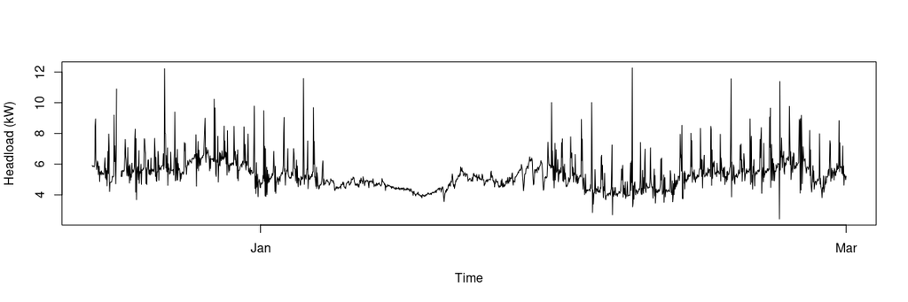

```r
plot(D$t, D$heatload, type="l", xlab="Time", ylab="Headload (kW)")
```

The convention used in all examples is that the time points are always set to the time interval end point, e.g.:

```r
## The observation
D$heatload[2]
```

```
##     [1] 5.85
## Represents the average load between
```

```r
D$t[1]
```

```
##     [1] "2010-12-15 01:00:00 GMT"
## and
```

```r
D$t[2]
```

```
##     [1] "2010-12-15 02:00:00 GMT"
```

The main idea behind setting the time point at the end of the interval is: Working with values averaged over the time interval, such values are available at the end of the time interval, not before. Especially, in real-time applications this is a useful convention.

### Forecasts

As described in [onlineforecasting](https://onlineforecasting.org/articles/onlineforecasting.pdf) the setup of forecasts for model inputs always follows the same format - as presented in the following. This is also the format of the forecasts generated by functions in the package. Hence all forecasts must follow this format.

The rules are:

- All values at row `i` are available at the `i`’th value in time `t`.
- All columns must be named with `k` followed by an integer indicating the horizon in steps (e.g. the column named `k8` hold the 8-step forecasts).

Have a look at the forecasts of the global radiation:

```r
## Global radiation forecasts
head(D$I)
```

```
##       k1 k2   k3    k4    k5    k6    k7    k8     k9    k10    k11   k12  k13  k14
##     1  0  0  0.0   0.0   0.0   0.0   0.0  46.9 119.52 168.41 181.49 158.5 97.6 19.4
##     2  0  0  0.0   0.0   0.0   0.0  46.9 119.5 168.41 181.49 158.52  97.6 19.4  0.0
##     3  0  0  0.0   0.0   0.0  46.9 119.5 168.4 181.49 158.52  97.64  19.4  0.0  0.0
##     4  0  0  0.0   0.0  49.9 125.6 175.0 190.6 165.10  99.86   9.94   0.0  0.0  0.0
##     5  0  0  0.0  49.9 125.6 175.0 190.6 165.1  99.86   9.94   0.00   0.0  0.0  0.0
##     6  0  0 49.9 125.6 175.0 190.6 165.1  99.9   9.94   0.00   0.00   0.0  0.0  0.0
##       k15 k16 k17 k18 k19 k20 k21 k22 k23 k24 k25 k26  k27  k28  k29  k30   k31
##     1   0   0   0   0   0   0   0   0   0   0   0   0  0.0  0.0  0.0  0.0   0.0
##     2   0   0   0   0   0   0   0   0   0   0   0   0  0.0  0.0  0.0  0.0  12.2
##     3   0   0   0   0   0   0   0   0   0   0   0   0  0.0  0.0  0.0 12.2  11.8
##     4   0   0   0   0   0   0   0   0   0   0   0   0  0.0  0.0 42.4 42.8  58.1
##     5   0   0   0   0   0   0   0   0   0   0   0   0  0.0 42.4 42.8 58.1  44.8
##     6   0   0   0   0   0   0   0   0   0   0   0   0 42.4 42.8 58.1 44.8 254.1
##         k32   k33  k34  k35  k36
##     1  12.2  11.8 15.5 12.3 24.1
##     2  11.8  15.5 12.3 24.1 38.7
##     3  15.5  12.3 24.1 38.7 31.4
##     4  44.8 254.1 20.6 30.3  0.0
##     5 254.1 169.4 17.2  0.0  0.0
##     6 168.5  40.4  0.0  0.0  0.0
```

At the first time point:

```r
## First time point
D$t[1]
```

```
##     [1] "2010-12-15 01:00:00 GMT"
```

the available forecast ahead in time is at the first row:

```r
## The forecast available ahead in time is in the first row
D$I[1, ]
```

```
##       k1 k2 k3 k4 k5 k6 k7   k8  k9 k10 k11 k12  k13  k14 k15 k16 k17 k18 k19 k20
##     1  0  0  0  0  0  0  0 46.9 120 168 181 159 97.6 19.4   0   0   0   0   0   0
##       k21 k22 k23 k24 k25 k26 k27 k28 k29 k30 k31  k32  k33  k34  k35  k36
##     1   0   0   0   0   0   0   0   0   0   0   0 12.2 11.8 15.5 12.3 24.1
```

We can plot that by:

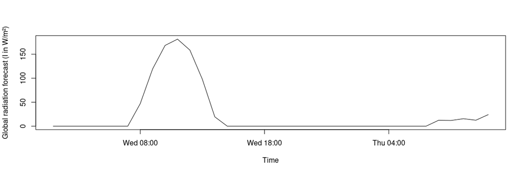

```r
i <- 1:ncol(D$I)
plot(D$t[i], D$I[1, ], type="l", xlab="Time", ylab="Global radiation forecast (I in W/m²)")
```

So this is the forecast available ahead in time at 2010-12-15 01:00:00.

The column in `I` named `k8` holds the 8-step horizon forecasts, which, since the steps are hourly, is an equi-distant time series. Picking out the entire series can be done by `D$I$k8` - hence a plot (together with the observations) can be generated by:

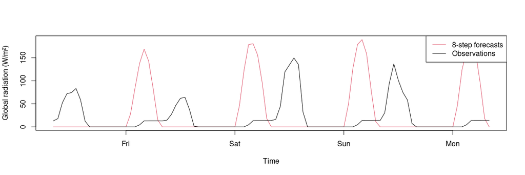

```r
## Just pick some points by
i <- 200:296
plot(D$t[i], D$I$k8[i], type="l", col=2, xlab="Time", ylab="Global radiation (W/m²)")
## Add the observations
lines(D$t[i], D$Iobs[i])
legend("topright", c("8-step forecasts","Observations"), bg="white", lty=1, col=2:1)
```

Notice how the are not aligned, since the forecasts are 8 hours ahead. To align them the forecasts must be lagged 8 steps by:

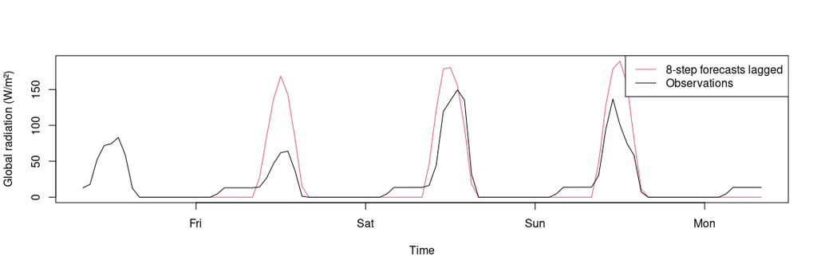

```r
plot(D$t[i], lagvec(D$I$k8[i], 8), type="l", col=2, xlab="Time", ylab="Global radiation (W/m²)")
lines(D$t[i], D$Iobs[i])
legend("topright", c("8-step forecasts lagged","Observations"), bg="white", lty=1, col=2:1)
```

## Plotting

A few simple plotting functions are included in the package.

### Time series plots

The plot function provided with the package actually does this lagging with plotting forecasts:

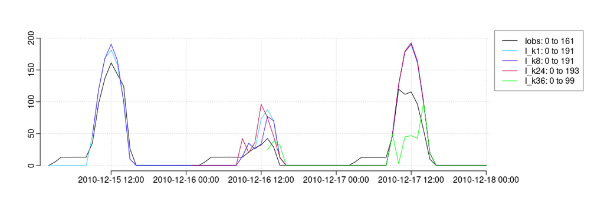

```r
plot_ts(D, patterns=c("^I"), c("2010-12-15","2010-12-18"), kseq=c(1,8,24,36))
```

The argument `patterns` is vector of a regular expressions (see `?regex`), which is used to match the variables to include in the plot. See the help with `?plot_ts` for more details.

An interactive plot can be generated using (first install the package `plotly`):

```r
plotly_ts(D, patterns=c("heatload$","^I"), c("2010-12-15","2010-12-18"), kseq=c(1,8,24,36))
```

Note that the `patterns` argument is a vector of regular expressions, which determines which variables from `D` to plot.

### Scatter plots

When modelling with the objective of forecasting, it’s always a good start to have a look at scatter plots between the model inputs and the model output. For example the heatload vs. ambient temperature 8-step forecast:

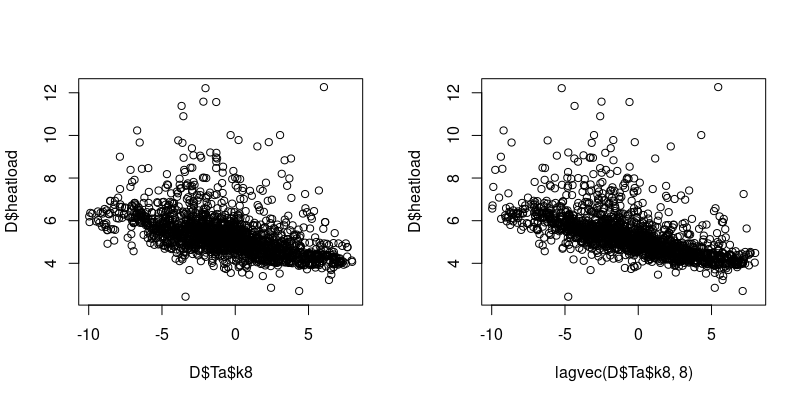

```r
par(mfrow=c(1,2))
plot(D$Ta$k8, D$heatload)
plot(lagvec(D$Ta$k8, 8), D$heatload)
```

So lagging (thus aligning in time) makes less slightly less scatter.

A wrapper for the `pairs` function is provided for a `data.list`, which can generate very useful explorative plots:

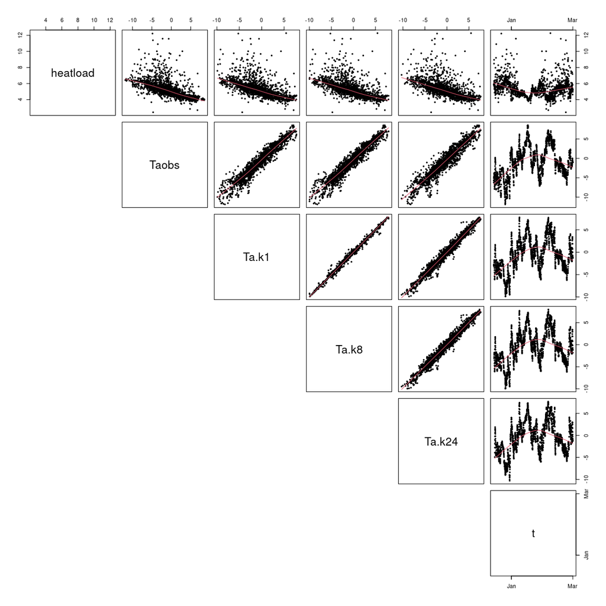

```r
pairs(D, nms=c("heatload","Taobs","Ta","t"), kseq=c(1,8,24))
```

Note how the sequence of included horizons are specified in the `kseq` argument, and note that the forecasts are lagged to be aligned in time. See `?pairs.data.list` for more details.

Just as a quick side note: This is the principle used for fitting onlineforecast models, simply shift forecasts to align with the observations:

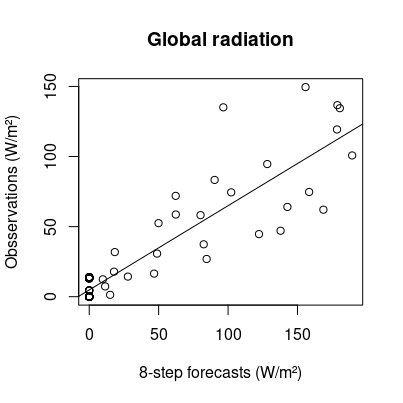

```r
## Lag the 8-step forecasts to be aligned with the observations
x <- lagvec(D$I$k8, 8)
## Take a smaller range
x <- x[i]
## Take the observations
y <- D$Iobs[i]
## Fit a linear regression model
fit <- lm(y ~ x)
## Plot the result
plot(x, y, xlab="8-step forecasts (W/m²)", ylab="Obsservations (W/m²)", main="Global radiation")
abline(fit)
```

Seen over time the 8-step forecasts are:

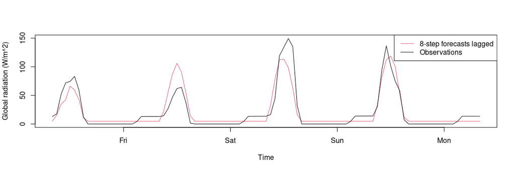

```r
plot(D$t[i], predict.lm(fit, newdata=data.frame(x)), type="l", ylim=c(0,max(y)), xlab="Time", ylab="Global radiation (W/m^2)", col=2)
lines(D$t[i], y)
legend("topright", c("8-step forecasts lagged","Observations"), lty=1, col=2:1)
```

Of course that model was very simple, see how to make a better model in [building-heat-load-forecasting] and more information on the [website].

## Subset

Taking a subset of a `data.list` is very useful and it can easily be done in different ways using the `subset` function (i.e. it’s really the `subset.data.list` function called when:

```r
## Take the 1 to 4 values of each variable in D
Dsub <- subset(D, 1:4)
summary(Dsub)
```

```
##                   Length Class      Mode
##     t              4     POSIXct    numeric
##     heatload       4     -none-     numeric
##     heatloadtotal  4     -none-     numeric
##     Taobs          4     -none-     numeric
##     Iobs           4     -none-     numeric
##     Ta            36     data.frame list
##     I             36     data.frame list
```

Another useful function for taking data in a time range is:

```r
which(in_range("2010-12-20",D$t,"2010-12-21"))
```

```
##      [1] 121 122 123 124 125 126 127 128 129 130 131 132 133 134 135 136 137 138 139
##     [20] 140 141 142 143 144
```

always check the help of function for more details (i.e. `?in_range`)

Actually, it’s easy to take subset from a period by:

```r
Dsub <- subset(D, c("2010-12-20","2010-12-21"))
summary(Dsub)
```

```
##                   Length Class      Mode
##     t             24     POSIXct    numeric
##     heatload      24     -none-     numeric
##     heatloadtotal 24     -none-     numeric
##     Taobs         24     -none-     numeric
##     Iobs          24     -none-     numeric
##     Ta            36     data.frame list
##     I             36     data.frame list
```

```r
Dsub$t
```

```
##      [1] "2010-12-20 01:00:00 GMT" "2010-12-20 02:00:00 GMT"
##      [3] "2010-12-20 03:00:00 GMT" "2010-12-20 04:00:00 GMT"
##      [5] "2010-12-20 05:00:00 GMT" "2010-12-20 06:00:00 GMT"
##      [7] "2010-12-20 07:00:00 GMT" "2010-12-20 08:00:00 GMT"
##      [9] "2010-12-20 09:00:00 GMT" "2010-12-20 10:00:00 GMT"
##     [11] "2010-12-20 11:00:00 GMT" "2010-12-20 12:00:00 GMT"
##     [13] "2010-12-20 13:00:00 GMT" "2010-12-20 14:00:00 GMT"
##     [15] "2010-12-20 15:00:00 GMT" "2010-12-20 16:00:00 GMT"
##     [17] "2010-12-20 17:00:00 GMT" "2010-12-20 18:00:00 GMT"
##     [19] "2010-12-20 19:00:00 GMT" "2010-12-20 20:00:00 GMT"
##     [21] "2010-12-20 21:00:00 GMT" "2010-12-20 22:00:00 GMT"
##     [23] "2010-12-20 23:00:00 GMT" "2010-12-21 00:00:00 GMT"
```

## Data.list to data.frame (or data.table)

It can be really useful to bring the data.list on a format of a `data.frame` or equivalently `data.table` for processing.

Bringing to `data.frame` can easily be done by:

```r
Df <- as.data.frame(Dsub)
names(Df)
```

```
##      [1] "t"             "heatload"      "heatloadtotal" "Taobs"
##      [5] "Iobs"          "Ta.k1"         "Ta.k2"         "Ta.k3"
##      [9] "Ta.k4"         "Ta.k5"         "Ta.k6"         "Ta.k7"
##     [13] "Ta.k8"         "Ta.k9"         "Ta.k10"        "Ta.k11"
##     [17] "Ta.k12"        "Ta.k13"        "Ta.k14"        "Ta.k15"
##     [21] "Ta.k16"        "Ta.k17"        "Ta.k18"        "Ta.k19"
##     [25] "Ta.k20"        "Ta.k21"        "Ta.k22"        "Ta.k23"
##     [29] "Ta.k24"        "Ta.k25"        "Ta.k26"        "Ta.k27"
##     [33] "Ta.k28"        "Ta.k29"        "Ta.k30"        "Ta.k31"
##     [37] "Ta.k32"        "Ta.k33"        "Ta.k34"        "Ta.k35"
##     [41] "Ta.k36"        "I.k1"          "I.k2"          "I.k3"
##     [45] "I.k4"          "I.k5"          "I.k6"          "I.k7"
##     [49] "I.k8"          "I.k9"          "I.k10"         "I.k11"
##     [53] "I.k12"         "I.k13"         "I.k14"         "I.k15"
##     [57] "I.k16"         "I.k17"         "I.k18"         "I.k19"
##     [61] "I.k20"         "I.k21"         "I.k22"         "I.k23"
##     [65] "I.k24"         "I.k25"         "I.k26"         "I.k27"
##     [69] "I.k28"         "I.k29"         "I.k30"         "I.k31"
##     [73] "I.k32"         "I.k33"         "I.k34"         "I.k35"
##     [77] "I.k36"
```

So the forecasts are just bind with the time and observations, and `.kxx` is added to the column names.

It can be converted to a `data.table` by:

```r
library(data.table)
setDT(Df)
class(Df)
```

```
##     [1] "data.table" "data.frame"
```

After processing it is easily converted back to the `data.list` again by:

```r
## Set back to data.frame
setDF(Df)
## Convert to a data.list
Dsub2 <- as.data.list(Df)
## Compare it with the original Dsub
summary(Dsub2)
```

```
##                   Length Class      Mode
##     t             24     POSIXct    numeric
##     heatload      24     -none-     numeric
##     heatloadtotal 24     -none-     numeric
##     Taobs         24     -none-     numeric
##     Iobs          24     -none-     numeric
##     Ta            36     data.frame list
##     I             36     data.frame list
```

```r
summary(Dsub)
```

```
##                   Length Class      Mode
##     t             24     POSIXct    numeric
##     heatload      24     -none-     numeric
##     heatloadtotal 24     -none-     numeric
##     Taobs         24     -none-     numeric
##     Iobs          24     -none-     numeric
##     Ta            36     data.frame list
##     I             36     data.frame list
```